# IODS course project

Jaakko Kähärä

# Chapter 1

I had used R a little previously, so getting started was easy. I managed to install all required packages and knit Exercise Set 1.

Dealing with Github has been quite annoying because the website has been really slow to update after pushing.

**R for Health Data Science** is helpful for getting started, but on some topics I would prefer more information and examples. I found Exercise Set 1 a useful companion to the book.

# Chapter 2

Exercise Set 2.

### Data Wrangling

I created “data” folder, and added R script “create_learning2014.R” in the folder. The script reads the learning2014 data from http://www.helsinki.fi/~kvehkala/JYTmooc/JYTOPKYS3-data.txt, and creates an analysis dataset which is saved in the data folder as learning2014.csv.

### Analysis

First we download the learning2014 data. In the file header is given in the first row, and the data separator is “,”.

```r
# read data
students2014 <- read.table("data/learning2014.csv", header = T, sep = ",")
# print dimesions of the table
dim(students2014)
```

```
## [1] 166   7
```

```r
# print first 6 rows
head(students2014)
```

```
##   gender age attitude points     deep     surf  stra
## 1      F  53       37     25 3.583333 2.583333 3.375
## 2      M  55       31     12 2.916667 3.166667 2.750
## 3      F  49       25     24 3.500000 2.250000 3.625
## 4      M  53       35     10 3.500000 2.250000 3.125
## 5      M  49       37     22 3.666667 2.833333 3.625
## 6      F  38       38     21 4.750000 2.416667 3.625
```

Dataset has 7 variables and 166 properties (rows). The variables are:

```
## [1] "gender"   "age"      "attitude" "points"   "deep"     "surf"     "stra"
```

Gender is `M` (Male), or `F` (Female), and age is given in years. Attitude describes the students total attitude toward statistics. Points are students’ exam results. `deep`, `surf`, and `stra` are averages taken over the students answers to questions on deep, surface and strategic learning.

Next, we can plot graphical overview of the data using `GGally` and `ggplot2` libraries. The variables are plotted separated in terms of gender.

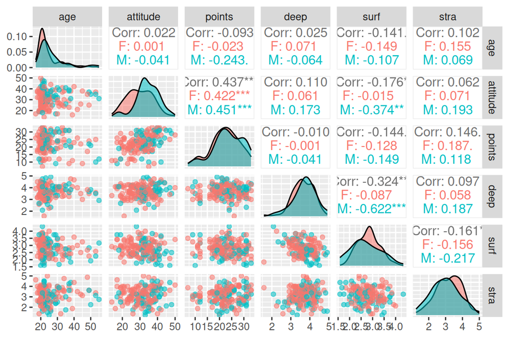

```r
# access the GGally and ggplot2 libraries
library(GGally)
library(ggplot2)

# create a more advanced plot matrix with ggpairs()
p <- ggpairs(students2014[-1], mapping = aes(col = students2014$gender, alpha = 0.3),
             lower = list(combo = wrap("facethist", bins = 20)))
# draw the plot
p
```

The plots in the diagonal show the density distributions of each value (red for female, blue for male). Scatter plots below the diagonal show how each pair of variables are related.

Above the diagonal are shown total and gender specific correlations between each pair of variables. The number of stars ’*’ next to each value tells how statistically significant the correlations are. The largest total correlation is between `attitude` and `points`. Interestingly, for male there is a very negative correlation between `deep` and `surf`, while for female these two are completely uncorrelated.

We see that `attitude`, `stra`, and `surf` have the largest correlation with `points`. Thus, we choose them as explanatory variables and fit them to a regression model with exam points as the target variable.

```r
# create a regression model with multiple explanatory variables
m <- lm(points ~ attitude + stra + surf, data = students2014)

# print out a summary of the model
summary(m)
```

```
##
## Call:
## lm(formula = points ~ attitude + stra + surf, data = students2014)
##
## Residuals:
##      Min       1Q   Median       3Q      Max
## -17.1550  -3.4346   0.5156   3.6401  10.8952
##
## Coefficients:
##             Estimate Std. Error t value Pr(>|t|)
## (Intercept) 11.01711    3.68375   2.991  0.00322 **
## attitude     0.33952    0.05741   5.913 1.93e-08 ***
## stra         0.85313    0.54159   1.575  0.11716
## surf        -0.58607    0.80138  -0.731  0.46563
## ---
## Signif. codes:  0 '***' 0.001 '**' 0.01 '*' 0.05 '.' 0.1 ' ' 1
##
## Residual standard error: 5.296 on 162 degrees of freedom
## Multiple R-squared:  0.2074, Adjusted R-squared:  0.1927
## F-statistic: 14.13 on 3 and 162 DF,  p-value: 3.156e-08
```

Looking at the summary, `surf` is does not have a statistically significant relationship (i.e. p-value is too large) with the target variable. We can remove it and refit the model.

```r
m2 <- lm(points ~ attitude + stra, data = students2014)
summary(m2)
```

```
##
## Call:
## lm(formula = points ~ attitude + stra, data = students2014)
##
## Residuals:
##      Min       1Q   Median       3Q      Max
## -17.6436  -3.3113   0.5575   3.7928  10.9295
##
## Coefficients:
##             Estimate Std. Error t value Pr(>|t|)
## (Intercept)  8.97290    2.39591   3.745  0.00025 ***
## attitude     0.34658    0.05652   6.132 6.31e-09 ***
## stra         0.91365    0.53447   1.709  0.08927 .
## ---
## Signif. codes:  0 '***' 0.001 '**' 0.01 '*' 0.05 '.' 0.1 ' ' 1
##
## Residual standard error: 5.289 on 163 degrees of freedom
## Multiple R-squared:  0.2048, Adjusted R-squared:  0.1951
## F-statistic: 20.99 on 2 and 163 DF,  p-value: 7.734e-09
```

P-values for the remaining variables are now smaller, and the model’s explanatory power is better. There is strong positive correlation between `attitude` and the target variable, but `stra` (strategic learning) has also a small effect.

Multiple R-squared tells how well the variables explain the variation of the target. In this case only 20.48 % of variation of exam points is explained by `attitude` and `stra`. The explanatory power of the model is quite low.

We can use the model produce the following diagnostic plots: Residuals vs Fitted values, Normal QQ-plot and Residuals vs Leverage.

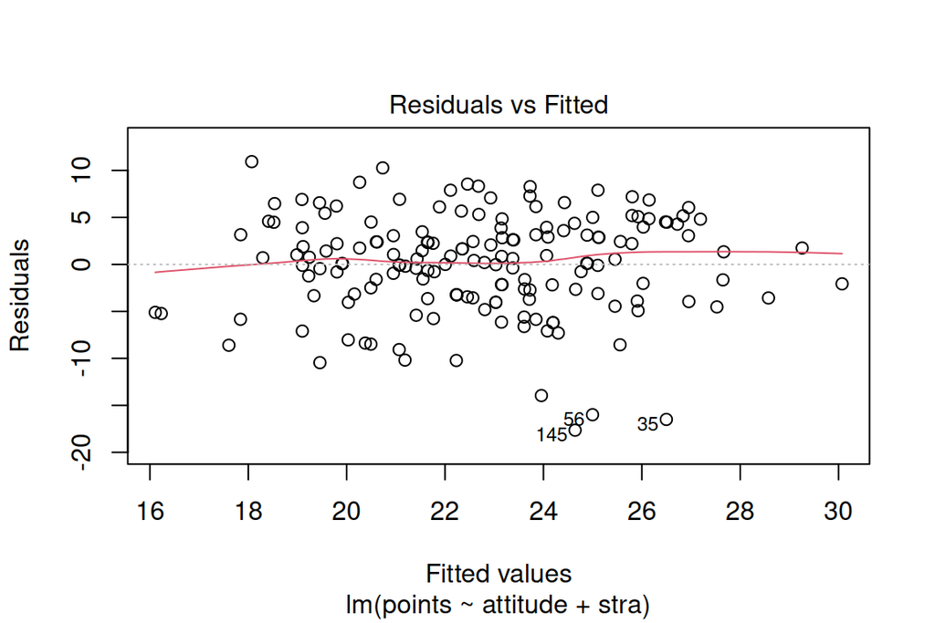

```r
# Plot residuals vs fitted values
plot(m2, which = c(1))
```

The model assumes a linear regression. If the “Residuals vs Fitted” plot were curved, we might need to include a quadratic term in the model. Based on the plot, a linear model is sufficient. Points 56, 35, and 145 are the biggest outliers.

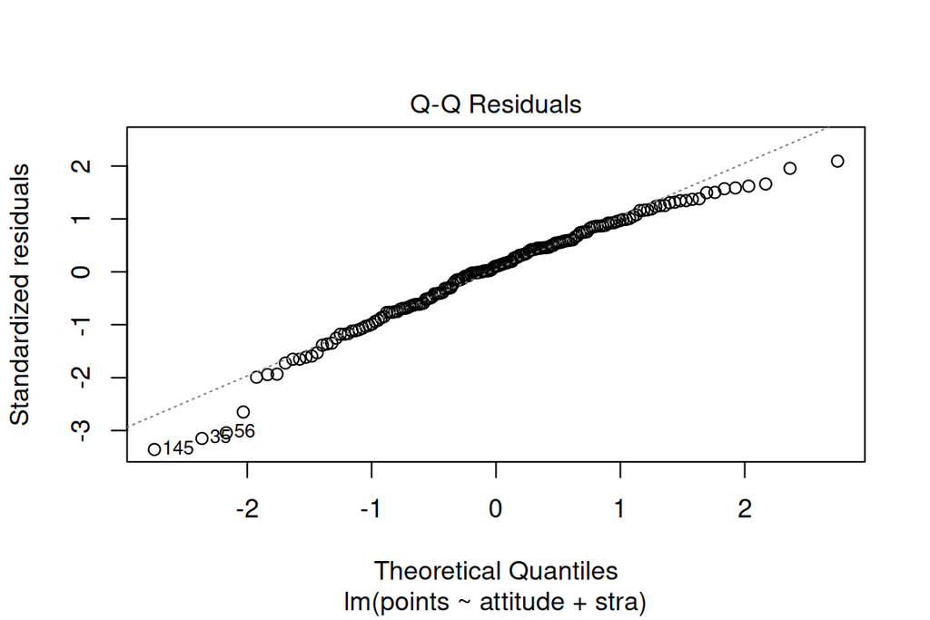

```r
# Plot Q-Q residuals
plot(m2, which = c(2))
```

“Q-Q Residuals” follows fairly closely to the straight line apart from a few outliers. This shows that the prediction errors are close to a normal distribution.

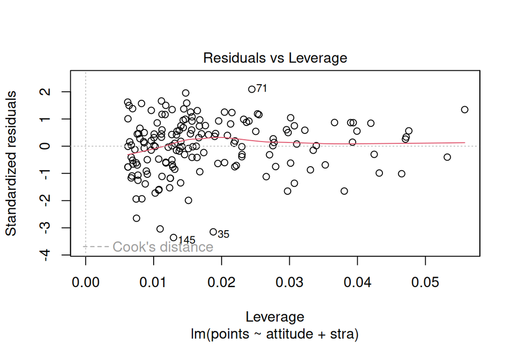

```r
# Plot residuals vs Leverage
plot(m2, which = c(5))
```

Leverage is a measure of how much influence each point has on the model prediction. In “Residuals vs Leverage”, we see that all leverage values are small, but some points have a proportionally larger effect.

# Chapter 3

Exercise Set 3.

### Data Wrangling

I downloaded data from http://www.archive.ics.uci.edu/dataset/320/student+performance, and added R script `create_alc.R` in the folder. The scrips merges two datasets of student alcohol consumption, and saves the result in the `data` folder as `alc_use.csv`. We only keep students present in both data sets. There are 370 students and 35 varibles in the joined data.

*This data approach student achievement in secondary education of two Portuguese schools. The data attributes include student grades, demographic, social and school related features) and it was collected by using school reports and questionnaires. Two datasets are provided regarding the performance in two distinct subjects: Mathematics (mat) and Portuguese language (por). In [Cortez and Silva, 2008], the two datasets were modeled under binary/five-level classification and regression tasks. Important note: the target attribute G3 has a strong correlation with attributes G2 and G1. This occurs because G3 is the final year grade (issued at the 3rd period), while G1 and G2 correspond to the 1st and 2nd period grades. It is more difficult to predict G3 without G2 and G1, but such prediction is much more useful (see paper source for more details).*

Firstly, we can download and glimpse at the data from `alc_use.csv`:

```r
# access the tidyverse libraries tidyr, dplyr, ggplot2
library(tidyr); library(dplyr); library(ggplot2)
# read data
alc <- read.table("data/alc_use.csv", header = T, sep = ",")
# glimpse at the data
glimpse(alc)
```

```
## Rows: 370
## Columns: 35
## $ school     <chr> "GP", "GP", "GP", "GP", "GP", "GP", "GP", "GP", "GP", "GP",…
## $ sex        <chr> "F", "F", "F", "F", "F", "M", "M", "F", "M", "M", "F", "F",…
## $ age        <int> 18, 17, 15, 15, 16, 16, 16, 17, 15, 15, 15, 15, 15, 15, 15,…
## $ address    <chr> "U", "U", "U", "U", "U", "U", "U", "U", "U", "U", "U", "U",…
## $ famsize    <chr> "GT3", "GT3", "LE3", "GT3", "GT3", "LE3", "LE3", "GT3", "LE…
## $ Pstatus    <chr> "A", "T", "T", "T", "T", "T", "T", "A", "A", "T", "T", "T",…
## $ Medu       <int> 4, 1, 1, 4, 3, 4, 2, 4, 3, 3, 4, 2, 4, 4, 2, 4, 4, 3, 3, 4,…
## $ Fedu       <int> 4, 1, 1, 2, 3, 3, 2, 4, 2, 4, 4, 1, 4, 3, 2, 4, 4, 3, 2, 3,…
## $ Mjob       <chr> "at_home", "at_home", "at_home", "health", "other", "servic…
## $ Fjob       <chr> "teacher", "other", "other", "services", "other", "other", …
## $ reason     <chr> "course", "course", "other", "home", "home", "reputation", …
## $ guardian   <chr> "mother", "father", "mother", "mother", "father", "mother",…
## $ traveltime <int> 2, 1, 1, 1, 1, 1, 1, 2, 1, 1, 1, 3, 1, 2, 1, 1, 1, 3, 1, 1,…
```

[output cut: 22 more lines]

### Analysis

The names of variables in the dataset are:

```
##  [1] "school"     "sex"        "age"        "address"    "famsize"
##  [6] "Pstatus"    "Medu"       "Fedu"       "Mjob"       "Fjob"
## [11] "reason"     "guardian"   "traveltime" "studytime"  "schoolsup"
## [16] "famsup"     "activities" "nursery"    "higher"     "internet"
## [21] "romantic"   "famrel"     "freetime"   "goout"      "Dalc"
## [26] "Walc"       "health"     "failures"   "paid"       "absences"
## [31] "G1"         "G2"         "G3"         "alc_use"    "high_use"
```

Two new columns have been added to the joined data: `alc_use` is the average of the answers related to weekday and weekend alcohol consumption, and `high_use` is set `TRUE` for students for which `alc_use` is greater than 2 (`FALSE` otherwise).

The purpose of this analysis is to study the relationships between high/low alcohol consumption and some of the other variables in the data. For example, we can create box plots of the final grades (`G3`) in terms of high use:

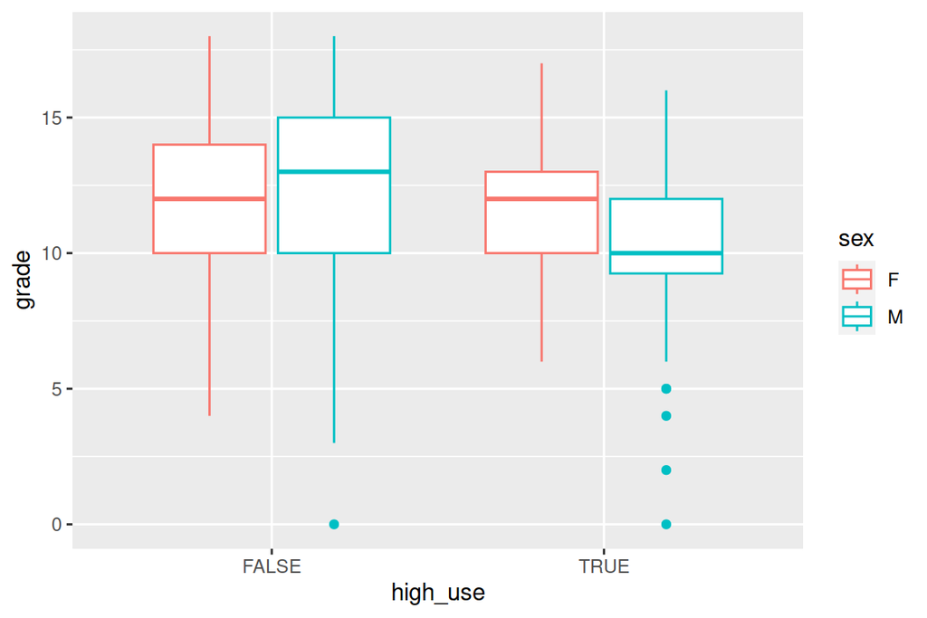

```r
# initialize a plot of high_use and G3
g1 <- ggplot(alc, aes(x = high_use, y = G3, col = sex))
g1 + geom_boxplot() + ylab("grade")
```

Grades of male high alcohol users are lower on average, but not for females. Because of the high variance in either case, grade itself is not a good predictor of alcohol use.

Here, I chose the following 4 variables in the data which appear to most strongly correlate with alcohol use: `sex`, `absences`, `failures`, and `goout` (frequency of going out with friends). The number of absences can be examined with a boxplot:

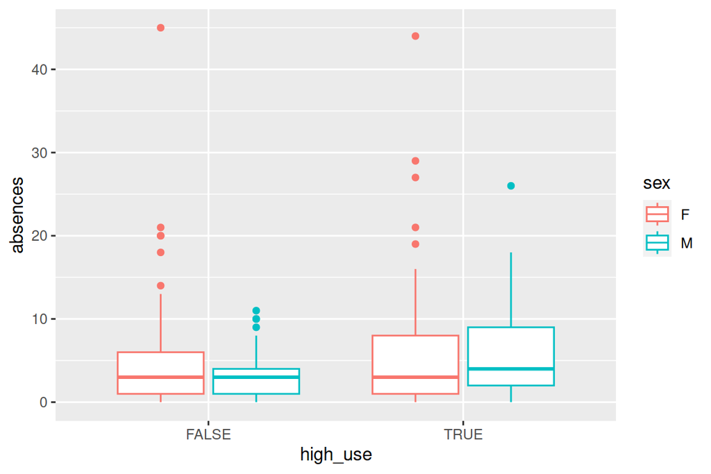

```r
# initialize a plot of high_use and absences
g2 <- ggplot(alc, aes(x = high_use, y = absences, col = sex))
g2 + geom_boxplot() + ylab("absences")
```

High alcohol use correlates positively with the number absences.

Similar results can be seen with the number of class failures and frequency of going out with friends. We can examining the effect of `goout` and `failures` by creating separate bar plots for low and high use.

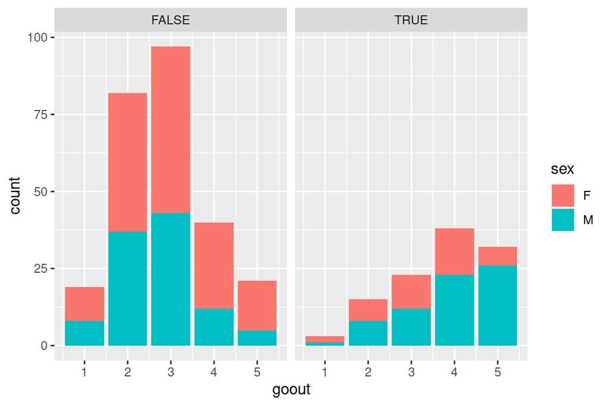

```r
# initialize a bar plot of high_use and goout
g1 <- ggplot(alc, aes(x = goout, fill=sex)) + geom_bar()
g1 + facet_wrap("high_use")
```

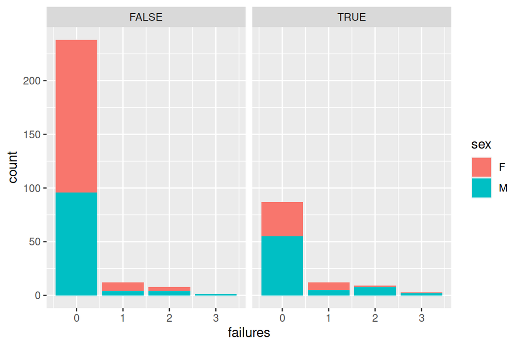

```r
g2 <- ggplot(alc, aes(x = failures, fill=sex)) + geom_bar()
g2 + facet_wrap("high_use")
```

For `failures` the correlation is not as noticeable, so we can also use `group_by()` to calculate the average number of class failures (divided by sex).

[output not shown]

```
## # A tibble: 4 × 5
## # Groups:   sex [2]
##   sex   high_use count  fail absent
##   <chr> <lgl>    <int> <dbl>  <dbl>
## 1 F     FALSE      154 0.104   4.25
## 2 F     TRUE        41 0.293   6.85
## 3 M     FALSE      105 0.143   2.91
## 4 M     TRUE        70 0.386   6.1
```

Next, we use logistic regression to statistically explore the relationship between the chosen variables and the binary high/low alcohol consumption variable as the target variable.

```
##
## Call:
## glm(formula = high_use ~ sex + absences + failures + goout, family = "binomial",
##     data = alc)
##
## Coefficients:
##             Estimate Std. Error z value Pr(>|z|)
## (Intercept) -4.14389    0.47881  -8.654  < 2e-16 ***
## sexM         0.97989    0.26156   3.746 0.000179 ***
## absences     0.08246    0.02266   3.639 0.000274 ***
## failures     0.48932    0.23073   2.121 0.033938 *
## goout        0.69801    0.12093   5.772 7.83e-09 ***
## ---
## Signif. codes:  0 '***' 0.001 '**' 0.01 '*' 0.05 '.' 0.1 ' ' 1
##
## (Dispersion parameter for binomial family taken to be 1)
##
##     Null deviance: 452.04  on 369  degrees of freedom
## Residual deviance: 369.50  on 365  degrees of freedom
## AIC: 379.5
##
## Number of Fisher Scoring iterations: 4
```

Variable `goout` has lowest p-value, meaning it most explanatory power in the model. `sex` and `absences` also have a high significance, while “failures” has a fairly low significance (high p-value).

The computational target variable in the logistic regression model is the log of odds:
$$\log\left( \frac{p}{1 - p}
\right).$$
Therefore we apply the exponent function to obtain the modeled ratios of propabilities:

```r
# compute odds ratios (OR)
OR <- coef(m) %>% exp

# compute confidence intervals (CI)
CI <- confint(m)
# print out the odds ratios with their confidence intervals
cbind(OR, CI)
```

```
##                     OR       2.5 %     97.5 %
## (Intercept) 0.01586098 -5.12422446 -3.2428932
## sexM        2.66415000  0.47316089  1.5009085
## absences    1.08595465  0.03922013  0.1293995
## failures    1.63121360  0.04208372  0.9518235
## goout       2.00975350  0.46657743  0.9418090
```

We can add prediction probabilities and predicted values (`TRUE` or `FALSE`) to the table, and perform 2x2 cross tabulation of predictions versus the actual values.

```r
# add prediction probabilities and predicted values (TRUE or FALSE)
alc <- mutate(alc, probability = predict(m, type = "response"))
alc <- mutate(alc, prediction = probability > 0.5)

# tabulate the target variable versus the predictions
table(high_use = alc$high_use, prediction = alc$prediction)
```

```
##         prediction
## high_use FALSE TRUE
##    FALSE   243   16
##    TRUE     61   50
```

In the table, inaccurately classified individuals are found in the off-diagonal values.

```r
# table of proportional values
t <- table(high_use = alc$high_use, prediction = alc$prediction) %>% prop.table() %>% addmargins()
t
```

```
##         prediction
## high_use      FALSE       TRUE        Sum
##    FALSE 0.65675676 0.04324324 0.70000000
##    TRUE  0.16486486 0.13513514 0.30000000
##    Sum   0.82162162 0.17837838 1.00000000
```

```r
# total fail rate
(t[1,2] + t[2,1])
```

```
## [1] 0.2081081
```

The training error (i.e. the percentage of wrong predictions) is 20.8%. The prediction accuracy is not too bad.

However, we can simplify the model by dropping both `failures` and `absences`:

```r
m <- glm(high_use ~ sex + goout, data = alc, family = "binomial")
# Summarise the model
summary(m)
```

```
##
## Call:
## glm(formula = high_use ~ sex + goout, family = "binomial", data = alc)
##
## Coefficients:
##             Estimate Std. Error z value Pr(>|z|)
## (Intercept)  -3.8193     0.4572  -8.354  < 2e-16 ***
## sexM          0.9268     0.2507   3.696 0.000219 ***
## goout         0.7578     0.1190   6.369  1.9e-10 ***
## ---
## Signif. codes:  0 '***' 0.001 '**' 0.01 '*' 0.05 '.' 0.1 ' ' 1
##
## (Dispersion parameter for binomial family taken to be 1)
##
##     Null deviance: 452.04  on 369  degrees of freedom
## Residual deviance: 388.94  on 367  degrees of freedom
## AIC: 394.94
##
## Number of Fisher Scoring iterations: 4
```

```r
alc <- mutate(alc, probability = predict(m, type = "response"))
alc <- mutate(alc, prediction = probability > 0.5)

# table of proportional values
t <- table(high_use = alc$high_use, prediction = alc$prediction) %>% prop.table() %>% addmargins()
# total fail rate
(t[1,2] + t[2,1])
```

```
## [1] 0.2135135
```

Failure rate is very similar at 21.3%, so clearly not all variables are necessary needed to get good predictions.

```r
# loss function (average prediction error)
loss_func <- function(class, prob) {
  n_wrong <- abs(class - prob) > 0.5
  mean(n_wrong)
}

# K-fold cross-validation
library(boot)
cv <- cv.glm(data = alc, cost = loss_func, glmfit = m, K = 10)

# average number of wrong predictions in the cross validation
cv$delta[1]
```

```
## [1] 0.2351351
```